# 项目：调查tmdb-movies数据集

## 目录

- 简介
- 数据整理
- 探索性数据分析
- 结论

## 简介

> 本次分析的数据集中包含 1 万条电影信息，信息来源为“电影数据库”（TMDb，The Movie Database），包括用户评分和票房等信息。

> 探索问题描述:

> 1.对于数据集中的每一年，该年度评分最高的电影是哪一部？

> 1.1对于每一年评分最高的电影，这些电影的类型集中在哪些类型？

> 2.按照不同的年份分组，根据调整过的预算和收益，电影的毛利润有什么趋势？

> 3.按照不同的年份分组，电影的受欢迎度有什么不同？

> 4.按照不同的年份分组，电影的发行数量是否越来越多了？

> 5.根据上映年份的不同，每年的平均毛利润和每年的平均评分有什么关系？

> 6.根据上映年份的不同，每年电影的平均评分走势是如何？

> 7.最常被用来描述电影的关键字是什么？

> *参考或使用的网站、书籍、论坛、博客帖子、GitHub 代码库等的列表:

> https://seaborn.pydata.org/

> https://amueller.github.io/word_cloud/

> https://matplotlib.org/index.html

> https://github.com/ShiChJ/DAND-QA/blob/master/Intro-DataAnalysis/Project-Data/Investigate_a_Dataset-zh.ipynb

> https://github.com/ShiChJ/DAND-QA/tree/master/Intro-DataAnalysis/Project-Data/Data-Dict

## 导入常用工具

```python
import pandas as pd
import numpy as np
import matplotlib.pyplot as plt
import seaborn as sns
from wordcloud import WordCloud
sns.set(style="whitegrid")
%matplotlib inline
```

## 数据整理

### 常规属性

#### 读取CSV文件

```python
df=pd.read_csv("tmdb-movies.csv")
```

```python
df.head()
```

|  | id | imdb_id | popularity | budget | revenue | original_title | cast | homepage | director | tagline | ... | overview | runtime | genres | production_companies | release_date | vote_count | vote_average | release_year | budget_adj | revenue_adj |
| --- | --- | --- | --- | --- | --- | --- | --- | --- | --- | --- | --- | --- | --- | --- | --- | --- | --- | --- | --- | --- | --- |
| 0 | 135397 | tt0369610 | 32.985763 | 150000000 | 1513528810 | Jurassic World | Chris Pratt\|Bryce Dallas Howard\|Irrfan Khan\|Vi... | http://www.jurassicworld.com/ | Colin Trevorrow | The park is open. | ... | Twenty-two years after the events of Jurassic ... | 124 | Action\|Adventure\|Science Fiction\|Thriller | Universal Studios\|Amblin Entertainment\|Legenda... | 6/9/15 | 5562 | 6.5 | 2015 | 1.379999e+08 | 1.392446e+09 |
| 1 | 76341 | tt1392190 | 28.419936 | 150000000 | 378436354 | Mad Max: Fury Road | Tom Hardy\|Charlize Theron\|Hugh Keays-Byrne\|Nic... | http://www.madmaxmovie.com/ | George Miller | What a Lovely Day. | ... | An apocalyptic story set in the furthest reach... | 120 | Action\|Adventure\|Science Fiction\|Thriller | Village Roadshow Pictures\|Kennedy Miller Produ... | 5/13/15 | 6185 | 7.1 | 2015 | 1.379999e+08 | 3.481613e+08 |
| 2 | 262500 | tt2908446 | 13.112507 | 110000000 | 295238201 | Insurgent | Shailene Woodley\|Theo James\|Kate Winslet\|Ansel... | http://www.thedivergentseries.movie/#insurgent | Robert Schwentke | One Choice Can Destroy You | ... | Beatrice Prior must confront her inner demons ... | 119 | Adventure\|Science Fiction\|Thriller | Summit Entertainment\|Mandeville Films\|Red Wago... | 3/18/15 | 2480 | 6.3 | 2015 | 1.012000e+08 | 2.716190e+08 |
| 3 | 140607 | tt2488496 | 11.173104 | 200000000 | 2068178225 | Star Wars: The Force Awakens | Harrison Ford\|Mark Hamill\|Carrie Fisher\|Adam D... | http://www.starwars.com/films/star-wars-episod... | J.J. Abrams | Every generation has a story. | ... | Thirty years after defeating the Galactic Empi... | 136 | Action\|Adventure\|Science Fiction\|Fantasy | Lucasfilm\|Truenorth Productions\|Bad Robot | 12/15/15 | 5292 | 7.5 | 2015 | 1.839999e+08 | 1.902723e+09 |
| 4 | 168259 | tt2820852 | 9.335014 | 190000000 | 1506249360 | Furious 7 | Vin Diesel\|Paul Walker\|Jason Statham\|Michelle ... | http://www.furious7.com/ | James Wan | Vengeance Hits Home | ... | Deckard Shaw seeks revenge against Dominic Tor... | 137 | Action\|Crime\|Thriller | Universal Pictures\|Original Film\|Media Rights ... | 4/1/15 | 2947 | 7.3 | 2015 | 1.747999e+08 | 1.385749e+09 |

5 rows × 21 columns

```python
df.tail()
```

|  | id | imdb_id | popularity | budget | revenue | original_title | cast | homepage | director | tagline | ... | overview | runtime | genres | production_companies | release_date | vote_count | vote_average | release_year | budget_adj | revenue_adj |
| --- | --- | --- | --- | --- | --- | --- | --- | --- | --- | --- | --- | --- | --- | --- | --- | --- | --- | --- | --- | --- | --- |
| 10861 | 21 | tt0060371 | 0.080598 | 0 | 0 | The Endless Summer | Michael Hynson\|Robert August\|Lord 'Tally Ho' B... | NaN | Bruce Brown | NaN | ... | The Endless Summer, by Bruce Brown, is one of ... | 95 | Documentary | Bruce Brown Films | 6/15/66 | 11 | 7.4 | 1966 | 0.000000 | 0.0 |
| 10862 | 20379 | tt0060472 | 0.065543 | 0 | 0 | Grand Prix | James Garner\|Eva Marie Saint\|Yves Montand\|Tosh... | NaN | John Frankenheimer | Cinerama sweeps YOU into a drama of speed and ... | ... | Grand Prix driver Pete Aron is fired by his te... | 176 | Action\|Adventure\|Drama | Cherokee Productions\|Joel Productions\|Douglas ... | 12/21/66 | 20 | 5.7 | 1966 | 0.000000 | 0.0 |
| 10863 | 39768 | tt0060161 | 0.065141 | 0 | 0 | Beregis Avtomobilya | Innokentiy Smoktunovskiy\|Oleg Efremov\|Georgi Z... | NaN | Eldar Ryazanov | NaN | ... | An insurance agent who moonlights as a carthie... | 94 | Mystery\|Comedy | Mosfilm | 1/1/66 | 11 | 6.5 | 1966 | 0.000000 | 0.0 |
| 10864 | 21449 | tt0061177 | 0.064317 | 0 | 0 | What's Up, Tiger Lily? | Tatsuya Mihashi\|Akiko Wakabayashi\|Mie Hama\|Joh... | NaN | Woody Allen | WOODY ALLEN STRIKES BACK! | ... | In comic Woody Allen's film debut, he took the... | 80 | Action\|Comedy | Benedict Pictures Corp. | 11/2/66 | 22 | 5.4 | 1966 | 0.000000 | 0.0 |
| 10865 | 22293 | tt0060666 | 0.035919 | 19000 | 0 | Manos: The Hands of Fate | Harold P. Warren\|Tom Neyman\|John Reynolds\|Dian... | NaN | Harold P. Warren | It's Shocking! It's Beyond Your Imagination! | ... | A family gets lost on the road and stumbles up... | 74 | Horror | Norm-Iris | 11/15/66 | 15 | 1.5 | 1966 | 127642.279154 | 0.0 |

5 rows × 21 columns

> budget列、revenue列、budget_adj列、revenue_adj列都存在为0的数值。

> homepage列和tagline列有缺失值。

#### 查看数据集的行数和列数

```python
print("Columns:",df.shape[0],"Rows:",df.shape[1])
```

```
Columns: 10866 Rows: 21
```

#### 查看数据的类型，以及数据集是否有存在缺失值

```python
df.info()
```

```
<class 'pandas.core.frame.DataFrame'>
RangeIndex: 10866 entries, 0 to 10865
Data columns (total 21 columns):
id                      10866 non-null int64
imdb_id                 10856 non-null object
popularity              10866 non-null float64
budget                  10866 non-null int64
revenue                 10866 non-null int64
original_title          10866 non-null object
cast                    10790 non-null object
homepage                2936 non-null object
director                10822 non-null object
tagline                 8042 non-null object
keywords                9373 non-null object
overview                10862 non-null object
runtime                 10866 non-null int64
genres                  10843 non-null object
production_companies    9836 non-null object
release_date            10866 non-null object
vote_count              10866 non-null int64
vote_average            10866 non-null float64
release_year            10866 non-null int64
budget_adj              10866 non-null float64
revenue_adj             10866 non-null float64
dtypes: float64(4), int64(6), object(11)
memory usage: 1.7+ MB
```

> budget列、revenue列、budget_adj列、revenue_adj列都存在为0的数值。我们后续会处理它。

#### 数据是否有重复行

```python
df.duplicated().idxmax()
```

```
2090
```

```python
df.iloc[209,5:6]
```

```
original_title    The Vatican Tapes
Name: 209, dtype: object
```

#### 查看重复行的信息

```python
df.query("original_title == 'TEKKEN'")
```

|  | id | imdb_id | popularity | budget | revenue | original_title | cast | homepage | director | tagline | ... | overview | runtime | genres | production_companies | release_date | vote_count | vote_average | release_year | budget_adj | revenue_adj |
| --- | --- | --- | --- | --- | --- | --- | --- | --- | --- | --- | --- | --- | --- | --- | --- | --- | --- | --- | --- | --- | --- |
| 2089 | 42194 | tt0411951 | 0.59643 | 30000000 | 967000 | TEKKEN | Jon Foo\|Kelly Overton\|Cary-Hiroyuki Tagawa\|Ian... | NaN | Dwight H. Little | Survival is no game | ... | In the year of 2039, after World Wars destroy ... | 92 | Crime\|Drama\|Action\|Thriller\|Science Fiction | Namco\|Light Song Films | 3/20/10 | 110 | 5.0 | 2010 | 30000000.0 | 967000.0 |
| 2090 | 42194 | tt0411951 | 0.59643 | 30000000 | 967000 | TEKKEN | Jon Foo\|Kelly Overton\|Cary-Hiroyuki Tagawa\|Ian... | NaN | Dwight H. Little | Survival is no game | ... | In the year of 2039, after World Wars destroy ... | 92 | Crime\|Drama\|Action\|Thriller\|Science Fiction | Namco\|Light Song Films | 3/20/10 | 110 | 5.0 | 2010 | 30000000.0 | 967000.0 |

2 rows × 21 columns

> 这两行的信息是完全重复的，重复的信息会影响我们后续的统计，所以我们在后续会删除重复的行。

### 数据清理

> keywords和genres存在缺失，正好，我们此次研究的问题和这两列有关系，但是我们无法得知缺失的值，这些缺失值也不能用平均值或者中位数来替代。

> 最后，我打算所以用" "(空格)填补，以免对后续分析造成影响。

```python
df.fillna(value=" ",inplace=True)
```

#### 查看对缺失值的处理是否成功

```python
df.isnull().any()
```

```
id                      False
imdb_id                 False
popularity              False
budget                  False
revenue                 False
original_title          False
cast                    False
homepage                False
director                False
tagline                 False
keywords                False
overview                False
runtime                 False
genres                  False
production_companies    False
release_date            False
vote_count              False
vote_average            False
release_year            False
budget_adj              False
revenue_adj             False
dtype: bool
```

#### 按年分组，查看budget_adj列和revenue_adj列的统计性数值

```python
df.groupby("release_year").describe()[["budget_adj","revenue_adj"]]
```

| release_year | budget_adj count | budget_adj mean | budget_adj std | budget_adj min | budget_adj 25% | budget_adj 50% | budget_adj 75% | budget_adj max | revenue_adj count | revenue_adj mean | revenue_adj std | revenue_adj min | revenue_adj 25% | revenue_adj 50% | revenue_adj 75% | revenue_adj max |
| --- | --- | --- | --- | --- | --- | --- | --- | --- | --- | --- | --- | --- | --- | --- | --- | --- |
| 1960 | 32.0 | 5.082036e+06 | 1.633279e+07 | 0.0 | 0.0 | 0.000000e+00 | 5.345401e+05 | 8.847561e+07 | 32.0 | 3.340991e+07 | 9.176779e+07 | 0.0 | 0.0 | 0.000000e+00 | 0.000000e+00 | 4.423780e+08 |
| 1961 | 31.0 | 1.085687e+07 | 1.551230e+07 | 0.0 | 0.0 | 0.000000e+00 | 2.151984e+07 | 4.376917e+07 | 31.0 | 7.947167e+07 | 2.860529e+08 | 0.0 | 0.0 | 0.000000e+00 | 3.027367e+07 | 1.574815e+09 |
| 1962 | 32.0 | 1.232693e+07 | 2.862812e+07 | 0.0 | 0.0 | 0.000000e+00 | 9.551195e+06 | 1.081267e+08 | 32.0 | 4.856238e+07 | 1.282817e+08 | 0.0 | 0.0 | 0.000000e+00 | 1.126320e+07 | 5.045914e+08 |
| 1963 | 34.0 | 1.535687e+07 | 4.354751e+07 | 0.0 | 0.0 | 0.000000e+00 | 6.675168e+06 | 2.215444e+08 | 34.0 | 3.924580e+07 | 1.181207e+08 | 0.0 | 0.0 | 0.000000e+00 | 0.000000e+00 | 5.617734e+08 |
| 1964 | 42.0 | 6.608980e+06 | 1.999008e+07 | 0.0 | 0.0 | 0.000000e+00 | 3.427255e+05 | 1.195145e+08 | 42.0 | 5.707603e+07 | 1.866875e+08 | 0.0 | 0.0 | 0.000000e+00 | 0.000000e+00 | 8.780804e+08 |
| 1965 | 35.0 | 1.388168e+07 | 3.195159e+07 | 0.0 | 0.0 | 0.000000e+00 | 1.193797e+06 | 1.384113e+08 | 35.0 | 9.057670e+07 | 2.760646e+08 | 0.0 | 0.0 | 0.000000e+00 | 0.000000e+00 | 1.129535e+09 |
| 1966 | 46.0 | 8.405522e+06 | 2.315491e+07 | 0.0 | 0.0 | 0.000000e+00 | 9.573171e+04 | 1.209243e+08 | 46.0 | 1.237527e+07 | 4.166699e+07 | 0.0 | 0.0 | 0.000000e+00 | 0.000000e+00 | 2.266436e+08 |
| 1967 | 40.0 | 1.644849e+07 | 3.403110e+07 | 0.0 | 0.0 | 0.000000e+00 | 2.042739e+07 | 1.634191e+08 | 40.0 | 1.205763e+08 | 2.677691e+08 | 0.0 | 0.0 | 0.000000e+00 | 8.043124e+07 | 1.345551e+09 |
| 1968 | 39.0 | 1.156367e+07 | 2.088939e+07 | 0.0 | 0.0 | 0.000000e+00 | 1.128413e+07 | 7.522756e+07 | 39.0 | 4.255388e+07 | 9.012507e+07 | 0.0 | 0.0 | 0.000000e+00 | 1.230179e+07 | 3.555466e+08 |
| 1969 | 31.0 | 8.078272e+06 | 1.694090e+07 | 0.0 | 0.0 | 0.000000e+00 | 4.785133e+06 | 7.133117e+07 | 31.0 | 4.677888e+07 | 1.434702e+08 | 0.0 | 0.0 | 0.000000e+00 | 0.000000e+00 | 6.081511e+08 |
| 1970 | 41.0 | 1.739252e+07 | 3.542332e+07 | 0.0 | 0.0 | 0.000000e+00 | 1.965729e+07 | 1.431331e+08 | 41.0 | 7.674178e+07 | 1.801806e+08 | 0.0 | 0.0 | 0.000000e+00 | 1.965729e+07 | 7.660726e+08 |
| 1971 | 55.0 | 7.441067e+06 | 1.719664e+07 | 0.0 | 0.0 | 0.000000e+00 | 7.929700e+06 | 1.077039e+08 | 55.0 | 3.964586e+07 | 1.077372e+08 | 0.0 | 0.0 | 0.000000e+00 | 6.561860e+06 | 6.246826e+08 |
| 1972 | 40.0 | 4.729510e+06 | 8.817016e+06 | 0.0 | 0.0 | 0.000000e+00 | 4.627923e+06 | 3.128737e+07 | 40.0 | 6.449502e+07 | 2.167584e+08 | 0.0 | 0.0 | 0.000000e+00 | 7.821841e+06 | 1.277914e+09 |
| 1973 | 55.0 | 5.821133e+06 | 1.461160e+07 | 0.0 | 0.0 | 0.000000e+00 | 2.455580e+06 | 7.366739e+07 | 55.0 | 1.092939e+08 | 3.338741e+08 | 0.0 | 0.0 | 0.000000e+00 | 2.908535e+07 | 2.167325e+09 |
| 1974 | 47.0 | 7.242196e+06 | 1.426383e+07 | 0.0 | 0.0 | 0.000000e+00 | 9.286796e+06 | 6.191197e+07 | 47.0 | 7.645280e+07 | 1.425195e+08 | 0.0 | 0.0 | 0.000000e+00 | 1.073138e+08 | 5.284629e+08 |
| 1975 | 44.0 | 5.182556e+06 | 1.237889e+07 | 0.0 | 0.0 | 0.000000e+00 | 2.431093e+06 | 6.077732e+07 | 44.0 | 8.817223e+07 | 2.984696e+08 | 0.0 | 0.0 | 0.000000e+00 | 5.232252e+07 | 1.907006e+09 |
| 1976 | 47.0 | 9.958339e+06 | 2.449853e+07 | 0.0 | 0.0 | 0.000000e+00 | 7.280226e+06 | 1.341094e+08 | 47.0 | 6.530237e+07 | 1.254268e+08 | 0.0 | 0.0 | 0.000000e+00 | 1.020430e+08 | 6.169034e+08 |
| 1977 | 57.0 | 1.019876e+07 | 1.999610e+07 | 0.0 | 0.0 | 0.000000e+00 | 1.223246e+07 | 7.915118e+07 | 57.0 | 1.376362e+08 | 4.146903e+08 | 0.0 | 0.0 | 0.000000e+00 | 9.503416e+07 | 2.789712e+09 |
| 1978 | 65.0 | 1.074791e+07 | 2.716819e+07 | 0.0 | 0.0 | 0.000000e+00 | 1.002810e+07 | 1.838485e+08 | 65.0 | 7.044251e+07 | 1.749057e+08 | 0.0 | 0.0 | 0.000000e+00 | 5.479689e+07 | 1.003539e+09 |
| 1979 | 57.0 | 1.343162e+07 | 2.800161e+07 | 0.0 | 0.0 | 0.000000e+00 | 1.201822e+07 | 1.051594e+08 | 57.0 | 8.880802e+07 | 1.434950e+08 | 0.0 | 0.0 | 0.000000e+00 | 1.136433e+08 | 6.318577e+08 |
| 1980 | 78.0 | 1.229729e+07 | 2.651335e+07 | 0.0 | 0.0 | 0.000000e+00 | 1.250252e+07 | 1.428860e+08 | 78.0 | 5.999930e+07 | 1.713441e+08 | 0.0 | 0.0 | 4.609834e+06 | 5.873748e+07 | 1.424626e+09 |
| 1981 | 82.0 | 1.093101e+07 | 1.836808e+07 | 0.0 | 0.0 | 1.942535e+05 | 1.408937e+07 | 8.393668e+07 | 82.0 | 5.190054e+07 | 1.237459e+08 | 0.0 | 0.0 | 0.000000e+00 | 6.257528e+07 | 9.351169e+08 |
| 1982 | 81.0 | 1.221309e+07 | 2.092801e+07 | 0.0 | 0.0 | 0.000000e+00 | 1.807714e+07 | 1.129821e+08 | 81.0 | 6.858277e+07 | 2.110184e+08 | 0.0 | 0.0 | 0.000000e+00 | 6.122022e+07 | 1.791694e+09 |
| 1983 | 80.0 | 1.420610e+07 | 2.248933e+07 | 0.0 | 0.0 | 2.955571e+01 | 2.189312e+07 | 8.888607e+07 | 80.0 | 6.314877e+07 | 1.548665e+08 | 0.0 | 0.0 | 1.683305e+07 | 5.746558e+07 | 1.253819e+09 |
| 1984 | 105.0 | 1.457759e+07 | 2.308462e+07 | 0.0 | 0.0 | 1.679234e+06 | 1.889138e+07 | 1.217444e+08 | 105.0 | 5.268644e+07 | 1.192877e+08 | 0.0 | 0.0 | 6.716935e+01 | 5.893706e+07 | 6.989810e+08 |
| 1985 | 109.0 | 1.392460e+07 | 2.139916e+07 | 0.0 | 0.0 | 2.310969e+02 | 2.432599e+07 | 1.013583e+08 | 109.0 | 5.348319e+07 | 1.190968e+08 | 0.0 | 0.0 | 1.747976e+07 | 5.052151e+07 | 7.725728e+08 |
| 1986 | 121.0 | 1.158350e+07 | 1.729377e+07 | 0.0 | 0.0 | 0.000000e+00 | 1.989406e+07 | 7.957626e+07 | 121.0 | 4.936980e+07 | 1.020321e+08 | 0.0 | 0.0 | 1.173750e+07 | 6.336872e+07 | 7.098811e+08 |
| 1987 | 125.0 | 1.089202e+07 | 1.688065e+07 | 0.0 | 0.0 | 0.000000e+00 | 2.302897e+07 | 7.676322e+07 | 125.0 | 5.315246e+07 | 1.001639e+08 | 0.0 | 0.0 | 8.090573e+06 | 6.814562e+07 | 6.143853e+08 |
| 1988 | 145.0 | 1.176718e+07 | 2.070948e+07 | 0.0 | 0.0 | 0.000000e+00 | 1.475113e+07 | 1.290724e+08 | 145.0 | 4.755396e+07 | 1.097949e+08 | 0.0 | 0.0 | 5.501773e+06 | 3.735165e+07 | 6.542594e+08 |
| 1989 | 137.0 | 1.386204e+07 | 2.262713e+07 | 0.0 | 0.0 | 0.000000e+00 | 2.110782e+07 | 1.231289e+08 | 137.0 | 6.631404e+07 | 1.388282e+08 | 0.0 | 0.0 | 3.058694e+06 | 6.560213e+07 | 8.340611e+08 |
| 1990 | 132.0 | 1.630870e+07 | 2.646166e+07 | 0.0 | 0.0 | 0.000000e+00 | 2.378180e+07 | 1.168229e+08 | 132.0 | 6.720056e+07 | 1.544529e+08 | 0.0 | 0.0 | 9.019864e+06 | 5.137119e+07 | 8.427938e+08 |
| 1991 | 133.0 | 1.765094e+07 | 2.792901e+07 | 0.0 | 0.0 | 0.000000e+00 | 2.721858e+07 | 1.601093e+08 | 133.0 | 5.665942e+07 | 1.301228e+08 | 0.0 | 0.0 | 8.400422e+05 | 5.200779e+07 | 8.325683e+08 |
| 1992 | 133.0 | 1.684615e+07 | 2.518927e+07 | 0.0 | 0.0 | 0.000000e+00 | 2.641841e+07 | 1.243219e+08 | 133.0 | 7.101953e+07 | 1.375737e+08 | 0.0 | 0.0 | 1.170633e+07 | 6.847909e+07 | 7.833063e+08 |
| 1993 | 178.0 | 1.509155e+07 | 2.327317e+07 | 0.0 | 0.0 | 6.037880e+00 | 2.679309e+07 | 1.283049e+08 | 178.0 | 5.898085e+07 | 1.460790e+08 | 0.0 | 0.0 | 6.764766e+06 | 4.783749e+07 | 1.388863e+09 |
| 1994 | 184.0 | 1.782289e+07 | 2.795058e+07 | 0.0 | 0.0 | 0.000000e+00 | 3.015779e+07 | 1.691778e+08 | 184.0 | 5.672917e+07 | 1.500006e+08 | 0.0 | 0.0 | 0.000000e+00 | 2.988234e+07 | 1.159592e+09 |
| 1995 | 175.0 | 2.343420e+07 | 3.633370e+07 | 0.0 | 0.0 | 5.008384e+06 | 3.648966e+07 | 2.504192e+08 | 175.0 | 7.487098e+07 | 1.692074e+08 | 0.0 | 0.0 | 7.288926e+06 | 5.274675e+07 | 1.583050e+09 |
| 1996 | 204.0 | 2.512641e+07 | 3.302340e+07 | 0.0 | 0.0 | 6.603530e+06 | 4.170650e+07 | 1.390217e+08 | 204.0 | 5.664106e+07 | 1.313050e+08 | 0.0 | 0.0 | 5.311601e+04 | 4.573385e+07 | 1.135764e+09 |
| 1997 | 192.0 | 3.361543e+07 | 4.513381e+07 | 0.0 | 0.0 | 1.630152e+07 | 4.924419e+07 | 2.716921e+08 | 192.0 | 7.538870e+07 | 2.112238e+08 | 0.0 | 0.0 | 4.639293e+06 | 6.130165e+07 | 2.506406e+09 |
| 1998 | 210.0 | 2.866274e+07 | 4.151501e+07 | 0.0 | 0.0 | 1.906216e+06 | 4.013086e+07 | 1.872774e+08 | 210.0 | 6.047132e+07 | 1.222232e+08 | 0.0 | 0.0 | 8.327756e+04 | 5.860910e+07 | 7.408152e+08 |
| 1999 | 224.0 | 3.369195e+07 | 4.333113e+07 | 0.0 | 0.0 | 1.439958e+07 | 5.236211e+07 | 2.225390e+08 | 224.0 | 6.636262e+07 | 1.487121e+08 | 0.0 | 0.0 | 2.274414e+06 | 6.242712e+07 | 1.209981e+09 |
| 2000 | 227.0 | 3.209074e+07 | 4.005310e+07 | 0.0 | 0.0 | 1.519551e+07 | 5.065168e+07 | 1.614522e+08 | 227.0 | 6.124336e+07 | 1.157144e+08 | 0.0 | 0.0 | 0.000000e+00 | 6.742371e+07 | 6.918869e+08 |
| 2001 | 242.0 | 2.871069e+07 | 3.951426e+07 | 0.0 | 0.0 | 8.620417e+06 | 4.494932e+07 | 1.724083e+08 | 242.0 | 6.824115e+07 | 1.527872e+08 | 0.0 | 0.0 | 8.269917e+05 | 7.204616e+07 | 1.202518e+09 |
| 2002 | 266.0 | 2.686408e+07 | 3.766903e+07 | 0.0 | 0.0 | 1.060729e+07 | 4.242915e+07 | 1.697166e+08 | 266.0 | 6.673644e+07 | 1.528354e+08 | 0.0 | 0.0 | 6.342467e+05 | 6.401723e+07 | 1.122902e+09 |
| 2003 | 281.0 | 2.632182e+07 | 4.137288e+07 | 0.0 | 0.0 | 4.741411e+06 | 3.793128e+07 | 2.370705e+08 | 281.0 | 6.385821e+07 | 1.493053e+08 | 0.0 | 0.0 | 0.000000e+00 | 6.969377e+07 | 1.326278e+09 |
| 2004 | 307.0 | 2.696341e+07 | 4.222914e+07 | 0.0 | 0.0 | 5.772227e+06 | 3.463336e+07 | 2.308891e+08 | 307.0 | 6.315163e+07 | 1.423779e+08 | 0.0 | 0.0 | 6.972192e+05 | 6.559938e+07 | 1.061904e+09 |
| 2005 | 364.0 | 2.252539e+07 | 3.714250e+07 | 0.0 | 0.0 | 2.903065e+06 | 3.349690e+07 | 2.311286e+08 | 364.0 | 5.066509e+07 | 1.230264e+08 | 0.0 | 0.0 | 9.883986e+04 | 5.194760e+07 | 1.000353e+09 |
| 2006 | 408.0 | 1.936979e+07 | 3.629430e+07 | 0.0 | 0.0 | 5.408346e+05 | 2.190380e+07 | 2.920507e+08 | 408.0 | 4.314942e+07 | 1.117220e+08 | 0.0 | 0.0 | 4.128623e+04 | 4.082012e+07 | 1.152691e+09 |
| 2007 | 438.0 | 1.833353e+07 | 3.751810e+07 | 0.0 | 0.0 | 2.103337e+04 | 2.103337e+07 | 3.155006e+08 | 438.0 | 4.660877e+07 | 1.281248e+08 | 0.0 | 0.0 | 0.000000e+00 | 2.782460e+07 | 1.010654e+09 |
| 2008 | 496.0 | 1.588863e+07 | 3.289981e+07 | 0.0 | 0.0 | 0.000000e+00 | 1.823016e+07 | 2.278770e+08 | 496.0 | 3.967774e+07 | 1.102814e+08 | 0.0 | 0.0 | 0.000000e+00 | 2.019150e+07 | 1.014733e+09 |
| 2009 | 533.0 | 1.638843e+07 | 3.515350e+07 | 0.0 | 0.0 | 0.000000e+00 | 1.524601e+07 | 2.541001e+08 | 533.0 | 4.229631e+07 | 1.650970e+08 | 0.0 | 0.0 | 0.000000e+00 | 1.297354e+07 | 2.827124e+09 |
| 2010 | 490.0 | 1.915306e+07 | 4.289299e+07 | 0.0 | 0.0 | 0.000000e+00 | 2.000000e+07 | 4.250000e+08 | 490.0 | 4.481632e+07 | 1.288276e+08 | 0.0 | 0.0 | 0.000000e+00 | 1.600392e+07 | 1.063172e+09 |
| 2011 | 540.0 | 1.618922e+07 | 3.510084e+07 | 0.0 | 0.0 | 5.183129e+04 | 1.672212e+07 | 3.683713e+08 | 540.0 | 4.253789e+07 | 1.246314e+08 | 0.0 | 0.0 | 0.000000e+00 | 1.892081e+07 | 1.287184e+09 |
| 2012 | 588.0 | 1.336439e+07 | 3.475599e+07 | 0.0 | 0.0 | 0.000000e+00 | 8.666417e+06 | 2.469335e+08 | 588.0 | 3.984473e+07 | 1.368977e+08 | 0.0 | 0.0 | 0.000000e+00 | 3.368653e+06 | 1.443191e+09 |
| 2013 | 659.0 | 1.311873e+07 | 3.368950e+07 | 0.0 | 0.0 | 0.000000e+00 | 7.488267e+06 | 2.386885e+08 | 659.0 | 3.508866e+07 | 1.207551e+08 | 0.0 | 0.0 | 0.000000e+00 | 3.111712e+06 | 1.192711e+09 |
| 2014 | 700.0 | 1.042674e+07 | 2.970941e+07 | 0.0 | 0.0 | 0.000000e+00 | 4.605455e+06 | 2.302728e+08 | 700.0 | 3.201601e+07 | 1.056089e+08 | 0.0 | 0.0 | 0.000000e+00 | 1.334564e+06 | 8.797523e+08 |
| 2015 | 629.0 | 1.111100e+07 | 3.052940e+07 | 0.0 | 0.0 | 0.000000e+00 | 5.519998e+06 | 2.575999e+08 | 629.0 | 3.914379e+07 | 1.543759e+08 | 0.0 | 0.0 | 0.000000e+00 | 3.023531e+06 | 1.902723e+09 |

> 首先，我们可以看到，每年budget_adj和revenue_adj的MIN值都存在0。

> 根据实际，我觉得一个电影的制作成本和收益等于0是不切实际的。

> 并且后期，我们需要分析毛利润，所以，最好还是把0替换掉。

> 因为我无法得知一部电影的成本和收益，所以我准备对于存在0的数值，都用平均值去替代。

```python
df["budget_adj"]=df["budget_adj"].replace(0,df["budget_adj"].mean())
df["revenue_adj"]=df["revenue_adj"].replace(0,df["revenue_adj"].mean())
```

#### 查看是否处理成功

```python
print((df["budget_adj"]==0).sum(),(df["revenue_adj"]==0).sum())
```

```
0 0
```

#### 删除重复行

```python
df.drop_duplicates(inplace=True)
```

```python
df.duplicated().sum()
```

```
0
```

#### 删除与我们提问无关的列

```python
df.drop(['cast','homepage','tagline','overview','director','production_companies','release_date','budget','revenue'],axis=1,inplace=True)
```

#### 创建名为gross_profit_adj的列，代表了电影的毛利润

```python
df["gross_profit_adj"]=df["revenue_adj"]-df["budget_adj"]
```

#### 确认更改

```python
df.head()
```

|  | id | imdb_id | popularity | original_title | keywords | runtime | genres | vote_count | vote_average | release_year | budget_adj | revenue_adj | gross_profit_adj |
| --- | --- | --- | --- | --- | --- | --- | --- | --- | --- | --- | --- | --- | --- |
| 0 | 135397 | tt0369610 | 32.985763 | Jurassic World | monster\|dna\|tyrannosaurus rex\|velociraptor\|island | 124 | Action\|Adventure\|Science Fiction\|Thriller | 5562 | 6.5 | 2015 | 1.379999e+08 | 1.392446e+09 | 1.254446e+09 |
| 1 | 76341 | tt1392190 | 28.419936 | Mad Max: Fury Road | future\|chase\|post-apocalyptic\|dystopia\|australia | 120 | Action\|Adventure\|Science Fiction\|Thriller | 6185 | 7.1 | 2015 | 1.379999e+08 | 3.481613e+08 | 2.101614e+08 |
| 2 | 262500 | tt2908446 | 13.112507 | Insurgent | based on novel\|revolution\|dystopia\|sequel\|dyst... | 119 | Adventure\|Science Fiction\|Thriller | 2480 | 6.3 | 2015 | 1.012000e+08 | 2.716190e+08 | 1.704191e+08 |
| 3 | 140607 | tt2488496 | 11.173104 | Star Wars: The Force Awakens | android\|spaceship\|jedi\|space opera\|3d | 136 | Action\|Adventure\|Science Fiction\|Fantasy | 5292 | 7.5 | 2015 | 1.839999e+08 | 1.902723e+09 | 1.718723e+09 |
| 4 | 168259 | tt2820852 | 9.335014 | Furious 7 | car race\|speed\|revenge\|suspense\|car | 137 | Action\|Crime\|Thriller | 2947 | 7.3 | 2015 | 1.747999e+08 | 1.385749e+09 | 1.210949e+09 |

## 探索性数据分析

### 研究问题 1

### 数据集中的每一年，评分最高的电影是哪部？

#### 按年分组，查看vote_average列和vote_count列的统计性数值

```python
df.groupby("release_year").describe()[["vote_average","vote_count"]]
```

| release_year | vote_average count | vote_average mean | vote_average std | vote_average min | vote_average 25% | vote_average 50% | vote_average 75% | vote_average max | vote_count count | vote_count mean | vote_count std | vote_count min | vote_count 25% | vote_count 50% | vote_count 75% | vote_count max |
| --- | --- | --- | --- | --- | --- | --- | --- | --- | --- | --- | --- | --- | --- | --- | --- | --- |
| 1960 | 32.0 | 6.325000 | 0.863974 | 4.9 | 5.850 | 6.25 | 7.000 | 8.0 | 32.0 | 77.531250 | 210.555637 | 10.0 | 12.00 | 16.0 | 32.25 | 1180.0 |
| 1961 | 31.0 | 6.374194 | 0.690395 | 4.6 | 6.050 | 6.30 | 6.900 | 7.5 | 31.0 | 77.580645 | 185.167091 | 10.0 | 13.00 | 18.0 | 35.00 | 913.0 |
| 1962 | 32.0 | 6.343750 | 0.752603 | 4.9 | 5.800 | 6.45 | 6.925 | 7.7 | 32.0 | 74.750000 | 137.262640 | 10.0 | 12.75 | 17.5 | 43.25 | 560.0 |
| 1963 | 34.0 | 6.329412 | 0.636529 | 5.0 | 5.925 | 6.35 | 6.700 | 7.5 | 34.0 | 82.823529 | 139.786736 | 10.0 | 14.25 | 22.0 | 61.75 | 486.0 |
| 1964 | 42.0 | 6.211905 | 0.751974 | 4.6 | 5.700 | 6.40 | 6.775 | 7.7 | 42.0 | 74.690476 | 172.903820 | 10.0 | 12.00 | 15.5 | 32.75 | 804.0 |
| 1965 | 35.0 | 6.194286 | 0.719045 | 4.4 | 5.750 | 6.30 | 6.600 | 7.6 | 35.0 | 52.000000 | 114.196940 | 10.0 | 13.50 | 19.0 | 26.50 | 620.0 |
| 1966 | 46.0 | 6.128261 | 0.960246 | 1.5 | 5.700 | 6.00 | 6.700 | 7.9 | 46.0 | 31.739130 | 45.153287 | 10.0 | 13.00 | 15.5 | 27.50 | 286.0 |
| 1967 | 40.0 | 6.242500 | 0.819596 | 4.6 | 5.500 | 6.25 | 6.900 | 7.6 | 40.0 | 77.550000 | 161.528111 | 10.0 | 14.50 | 19.5 | 70.50 | 928.0 |
| 1968 | 39.0 | 6.379487 | 0.601393 | 5.4 | 5.950 | 6.30 | 6.900 | 7.7 | 39.0 | 108.128205 | 283.188163 | 10.0 | 13.50 | 29.0 | 65.00 | 1708.0 |
| 1969 | 31.0 | 5.961290 | 0.901361 | 3.9 | 5.400 | 6.00 | 6.700 | 7.3 | 31.0 | 55.903226 | 82.940282 | 10.0 | 12.50 | 19.0 | 43.50 | 379.0 |
| 1970 | 41.0 | 6.417073 | 0.774565 | 3.0 | 6.200 | 6.50 | 6.700 | 7.6 | 41.0 | 49.048780 | 100.693334 | 10.0 | 13.00 | 19.0 | 33.00 | 625.0 |
| 1971 | 55.0 | 6.420000 | 0.780171 | 2.9 | 6.100 | 6.50 | 7.000 | 7.7 | 55.0 | 92.381818 | 247.138025 | 10.0 | 15.50 | 31.0 | 69.00 | 1786.0 |
| 1972 | 40.0 | 6.535000 | 0.688570 | 5.3 | 6.000 | 6.50 | 7.000 | 8.3 | 40.0 | 135.825000 | 623.136808 | 10.0 | 12.75 | 19.0 | 50.25 | 3970.0 |
| 1973 | 55.0 | 6.703636 | 0.633907 | 4.8 | 6.500 | 6.80 | 7.050 | 7.7 | 55.0 | 94.054545 | 176.429654 | 10.0 | 14.50 | 31.0 | 107.50 | 1113.0 |
| 1974 | 47.0 | 6.395745 | 0.749770 | 4.8 | 6.000 | 6.40 | 6.850 | 8.1 | 47.0 | 110.787234 | 319.590835 | 10.0 | 15.00 | 26.0 | 48.50 | 2131.0 |
| 1975 | 44.0 | 6.390909 | 0.748275 | 3.8 | 5.900 | 6.40 | 6.925 | 8.0 | 44.0 | 138.363636 | 350.184409 | 10.0 | 14.75 | 23.0 | 52.50 | 1612.0 |
| 1976 | 47.0 | 6.340426 | 0.728208 | 4.6 | 5.900 | 6.40 | 6.900 | 7.8 | 47.0 | 100.425532 | 233.619883 | 10.0 | 14.00 | 27.0 | 75.00 | 1269.0 |
| 1977 | 57.0 | 6.147368 | 0.748357 | 4.6 | 5.700 | 6.10 | 6.500 | 7.9 | 57.0 | 140.894737 | 588.858905 | 10.0 | 12.00 | 25.0 | 49.00 | 4428.0 |
| 1978 | 65.0 | 6.130769 | 0.891789 | 3.1 | 5.800 | 6.10 | 6.700 | 8.0 | 65.0 | 75.353846 | 141.916066 | 10.0 | 13.00 | 30.0 | 51.00 | 786.0 |
| 1979 | 57.0 | 6.308772 | 0.928763 | 3.0 | 5.900 | 6.20 | 7.000 | 7.8 | 57.0 | 154.912281 | 400.984782 | 10.0 | 14.00 | 33.0 | 65.00 | 2724.0 |
| 1980 | 78.0 | 6.160256 | 0.732606 | 3.6 | 5.800 | 6.20 | 6.500 | 8.0 | 78.0 | 139.717949 | 498.154905 | 10.0 | 15.25 | 27.5 | 50.25 | 3954.0 |
| 1981 | 82.0 | 6.165854 | 0.785080 | 4.2 | 5.800 | 6.25 | 6.600 | 8.5 | 82.0 | 91.219512 | 288.115376 | 10.0 | 13.00 | 20.5 | 63.50 | 2506.0 |
| 1982 | 81.0 | 6.241975 | 0.848213 | 3.0 | 5.700 | 6.20 | 7.000 | 7.9 | 81.0 | 140.555556 | 333.486731 | 10.0 | 15.00 | 31.0 | 99.00 | 2110.0 |
| 1983 | 80.0 | 5.971250 | 1.031429 | 2.7 | 5.300 | 6.10 | 6.625 | 8.1 | 80.0 | 123.575000 | 393.116170 | 10.0 | 17.00 | 29.0 | 75.00 | 3101.0 |
| 1984 | 105.0 | 6.003810 | 0.887187 | 3.6 | 5.600 | 6.10 | 6.600 | 8.4 | 105.0 | 146.390476 | 355.366482 | 10.0 | 15.00 | 37.0 | 101.00 | 2692.0 |
| 1985 | 109.0 | 6.177064 | 0.761654 | 4.3 | 5.700 | 6.20 | 6.700 | 8.3 | 109.0 | 126.247706 | 388.010575 | 10.0 | 18.00 | 36.0 | 100.00 | 3785.0 |
| 1986 | 121.0 | 6.004959 | 0.849397 | 3.5 | 5.400 | 6.10 | 6.600 | 8.0 | 121.0 | 113.016529 | 239.696300 | 10.0 | 18.00 | 32.0 | 105.00 | 2027.0 |
| 1987 | 125.0 | 6.128800 | 0.848321 | 2.8 | 5.800 | 6.20 | 6.700 | 7.7 | 125.0 | 120.512000 | 228.518391 | 10.0 | 14.00 | 32.0 | 103.00 | 1311.0 |
| 1988 | 145.0 | 5.965517 | 0.839509 | 3.8 | 5.500 | 6.00 | 6.600 | 8.0 | 145.0 | 100.524138 | 267.245520 | 10.0 | 18.00 | 28.0 | 76.00 | 2800.0 |
| 1989 | 137.0 | 6.070073 | 0.856151 | 2.3 | 5.500 | 6.00 | 6.700 | 8.4 | 137.0 | 136.182482 | 327.385009 | 10.0 | 17.00 | 33.0 | 110.00 | 2436.0 |
| 1990 | 132.0 | 5.993939 | 0.776148 | 3.8 | 5.400 | 6.00 | 6.500 | 8.0 | 132.0 | 163.446970 | 346.862718 | 10.0 | 18.00 | 36.0 | 110.25 | 1939.0 |
| 1991 | 133.0 | 6.014286 | 0.838572 | 3.1 | 5.500 | 6.00 | 6.600 | 7.9 | 133.0 | 127.864662 | 373.762722 | 10.0 | 14.00 | 26.0 | 94.00 | 2836.0 |
| 1992 | 133.0 | 6.081203 | 0.779194 | 4.0 | 5.600 | 6.10 | 6.600 | 8.4 | 133.0 | 146.218045 | 307.298378 | 10.0 | 18.00 | 50.0 | 131.00 | 2121.0 |
| 1993 | 178.0 | 6.050000 | 0.911462 | 3.4 | 5.500 | 6.10 | 6.775 | 8.1 | 178.0 | 136.426966 | 345.910651 | 10.0 | 18.00 | 40.0 | 112.75 | 3169.0 |
| 1994 | 184.0 | 5.942391 | 0.882276 | 3.9 | 5.300 | 6.00 | 6.500 | 8.4 | 184.0 | 204.298913 | 732.473848 | 10.0 | 17.00 | 36.5 | 96.75 | 5754.0 |
| 1995 | 175.0 | 6.056000 | 0.886655 | 3.5 | 5.400 | 6.10 | 6.700 | 8.5 | 175.0 | 204.628571 | 469.146626 | 10.0 | 19.00 | 54.0 | 170.50 | 3535.0 |
| 1996 | 204.0 | 5.900980 | 0.847424 | 3.3 | 5.375 | 5.95 | 6.500 | 7.9 | 204.0 | 127.602941 | 259.513478 | 10.0 | 17.00 | 40.0 | 99.25 | 2000.0 |
| 1997 | 192.0 | 5.988542 | 0.811484 | 3.2 | 5.400 | 6.00 | 6.500 | 7.8 | 192.0 | 213.463542 | 497.845409 | 10.0 | 18.00 | 45.5 | 170.50 | 4654.0 |
| 1998 | 210.0 | 5.970476 | 0.872210 | 2.9 | 5.400 | 6.10 | 6.600 | 8.0 | 210.0 | 190.676190 | 392.543393 | 10.0 | 16.00 | 47.5 | 184.00 | 3396.0 |
| 1999 | 224.0 | 6.032589 | 0.900205 | 3.4 | 5.475 | 6.10 | 6.600 | 8.1 | 224.0 | 238.602679 | 679.657866 | 10.0 | 17.00 | 39.5 | 172.75 | 6351.0 |
| 2000 | 227.0 | 5.882379 | 0.894649 | 3.5 | 5.300 | 5.90 | 6.400 | 8.5 | 227.0 | 203.550661 | 425.810119 | 10.0 | 19.50 | 49.0 | 191.50 | 3531.0 |
| 2001 | 242.0 | 5.896281 | 0.856430 | 3.6 | 5.400 | 5.90 | 6.500 | 8.0 | 242.0 | 260.570248 | 648.723174 | 10.0 | 19.00 | 51.0 | 191.00 | 6079.0 |
| 2002 | 266.0 | 5.973308 | 0.818836 | 3.3 | 5.500 | 6.00 | 6.500 | 8.3 | 266.0 | 236.481203 | 556.939204 | 10.0 | 22.00 | 53.5 | 190.00 | 5114.0 |
| 2003 | 281.0 | 5.930961 | 0.851219 | 3.4 | 5.300 | 6.00 | 6.500 | 8.0 | 281.0 | 243.505338 | 596.396130 | 10.0 | 16.00 | 48.0 | 196.00 | 5636.0 |
| 2004 | 307.0 | 5.988599 | 0.850663 | 2.1 | 5.500 | 6.00 | 6.600 | 7.8 | 307.0 | 257.980456 | 493.050667 | 10.0 | 18.00 | 57.0 | 247.50 | 3550.0 |
| 2005 | 364.0 | 5.866484 | 0.921657 | 2.5 | 5.275 | 5.90 | 6.500 | 8.3 | 364.0 | 201.472527 | 460.692851 | 10.0 | 16.00 | 48.0 | 181.25 | 4914.0 |
| 2006 | 408.0 | 5.941422 | 0.863212 | 2.8 | 5.300 | 6.00 | 6.500 | 8.7 | 408.0 | 186.477941 | 406.785486 | 10.0 | 19.75 | 46.0 | 154.00 | 3181.0 |
| 2007 | 438.0 | 5.964384 | 0.906277 | 1.5 | 5.400 | 6.00 | 6.600 | 7.9 | 438.0 | 206.372146 | 449.508270 | 10.0 | 18.00 | 40.5 | 160.50 | 3428.0 |
| 2008 | 496.0 | 5.930847 | 0.945097 | 2.6 | 5.300 | 6.00 | 6.500 | 8.5 | 496.0 | 206.778226 | 604.875894 | 10.0 | 17.00 | 34.5 | 144.25 | 8432.0 |
| 2009 | 533.0 | 5.856660 | 0.937912 | 3.1 | 5.300 | 5.90 | 6.500 | 8.3 | 533.0 | 224.557223 | 637.928959 | 10.0 | 17.00 | 38.0 | 156.00 | 8458.0 |
| 2010 | 489.0 | 5.992843 | 1.021756 | 2.1 | 5.400 | 6.00 | 6.600 | 8.8 | 489.0 | 265.928425 | 715.303817 | 10.0 | 17.00 | 40.0 | 190.00 | 9767.0 |
| 2011 | 540.0 | 5.958519 | 0.987896 | 2.1 | 5.300 | 6.00 | 6.600 | 9.2 | 540.0 | 250.812963 | 567.282357 | 10.0 | 17.00 | 45.5 | 194.50 | 5025.0 |
| 2012 | 588.0 | 5.799830 | 1.020764 | 2.0 | 5.200 | 5.80 | 6.500 | 8.3 | 588.0 | 312.141156 | 909.899728 | 10.0 | 16.00 | 35.0 | 169.50 | 8903.0 |
| 2013 | 659.0 | 5.880577 | 1.050959 | 2.2 | 5.250 | 5.90 | 6.600 | 8.5 | 659.0 | 325.471927 | 746.413227 | 10.0 | 17.00 | 40.0 | 191.50 | 6882.0 |
| 2014 | 700.0 | 5.920714 | 1.058983 | 2.4 | 5.200 | 6.00 | 6.700 | 8.8 | 700.0 | 294.660000 | 701.833620 | 10.0 | 18.00 | 45.0 | 190.50 | 6498.0 |
| 2015 | 629.0 | 5.885692 | 1.087283 | 2.4 | 5.200 | 5.90 | 6.700 | 8.9 | 629.0 | 290.019078 | 702.598425 | 10.0 | 18.00 | 44.0 | 197.00 | 6185.0 |

> 我们可以看到,发行日期在1960的最高vote_average是8.0，投票次数（vote_count）最高是1180次。一直到2015年，都有显示相关的数值。

#### 为每年的vote_average列创建箱线图

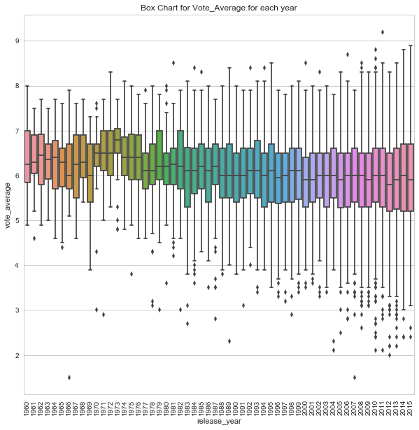

```python
plt.figure(figsize=(10,10))
plt.xticks(rotation='vertical')
plt.title("Box Chart for Vote_Average for each year")
ax = sns.boxplot(x="release_year", y="vote_average", data=df)
```

> 根据为vote_average列创建的箱线图，我们可以发现数据有一些异常值。但是关系应该不大，因为有评分高的电影，也有评分低的电影，这很正常。

#### 为每年的vote_count列创建箱线图

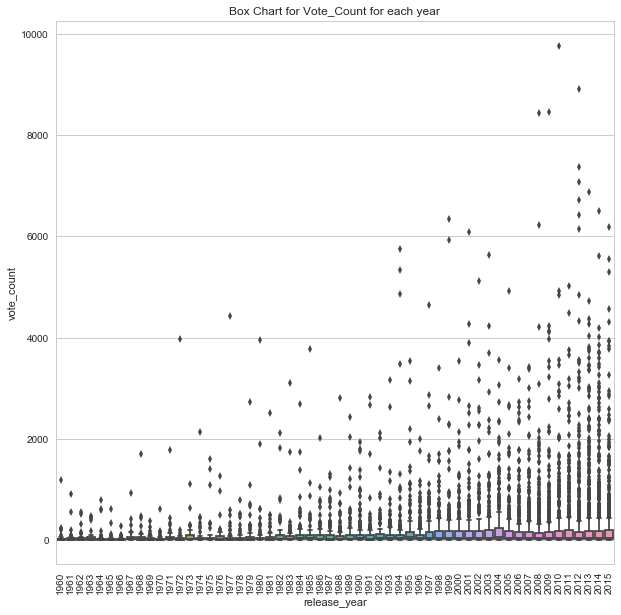

```python
plt.figure(figsize=(10,10))
plt.xticks(rotation='vertical')
plt.title("Box Chart for Vote_Count for each year")
ax = sns.boxplot(x="release_year", y="vote_count", data=df)
```

> 根据为vote_count列创建的箱线图，我们可以发现数据存在很多异常值。而且vote_count列的下限值很低。

```python
df.query("release_year == 2015")["vote_count"].idxmin()
```

```
240
```

```python
df.iloc[240]
```

```
id                           363689
imdb_id                   tt4229298
popularity                   0.5327
original_title         The Unspoken
keywords
runtime                          90
genres              Thriller|Horror
vote_count                       10
vote_average                    4.1
release_year                   2015
budget_adj               1.7551e+07
revenue_adj             5.13644e+07
gross_profit_adj        3.38133e+07
Name: 240, dtype: object
```

```python
df.query("release_year == 2015")["vote_average"].idxmax()
```

```
538
```

```python
df.iloc[538]
```

```
id                                                           224972
imdb_id                                                   tt3983674
popularity                                                 0.114264
original_title                                 The Mask You Live In
keywords            feminism|sexism|young boy|gender roles|misogyny
runtime                                                          88
genres                                                  Documentary
vote_count                                                       11
vote_average                                                    8.9
release_year                                                   2015
budget_adj                                               1.7551e+07
revenue_adj                                             5.13644e+07
gross_profit_adj                                        3.38133e+07
Name: 538, dtype: object
```

> 比方说：

> 在2015年，id为363689的这部电影，vote_average是4.1，但是vote_count只有10次。

> 在2015年，id为224972的这部电影，vote_average是8.9，但是vote_count只有11次。

> 我觉得这样的数据,在目前来看，不具有特别大的代表性。

### 创建名为df_vote的数据集，vote_count按大于平均vote_count筛选，把每年vote_average最高的电影添加进去。

```python
max_year_list=[]
max_title_list=[]
max_vote_average_list=[]
max_genres=[]

for _ in sorted(df["release_year"].unique()):
    df_new=df[(df["release_year"] == _) & (df["vote_count"] > df["vote_count"].mean())]
    max_year_list.append(_)
    max_title_list.append(df.iloc[df_new["vote_average"].idxmax()][3])
    max_vote_average_list.append(df.iloc[df_new["vote_average"].idxmax()][8])
    max_genres.append(df.iloc[df_new["vote_average"].idxmax()][6])

df_vote=pd.DataFrame({
    "Year":max_year_list,
    "Title":max_title_list,
    "Vote_Average":max_vote_average_list,
    "Genres":max_genres
})
```

#### 为每年最高评分的电影创建直方图

[figure not shown]

```python
vote_average=df_vote["Vote_Average"]
movie_title=df_vote["Title"]
width=movie_title
heights=vote_average
plt.figure(figsize=(10,10))
sns.barplot(width,heights)
plt.xticks(rotation='vertical')
plt.title("Most Voted Movie Of Each Year 1960-2015")
plt.xlabel("Title")
plt.ylabel("Average Vote");
```

### 研究问题1.1

### 对于每一年的高评分电影，类型集中在哪些类型？

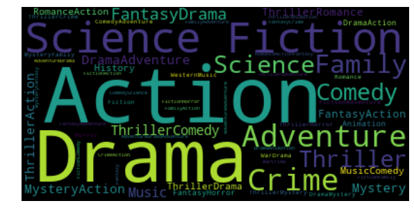

```python
wordcloud_max_genres = WordCloud(max_font_size=80).generate(''.join(df_vote["Genres"]))
WordCloud.generate_from_frequencies
plt.figure(figsize=(10,10))
plt.imshow(wordcloud_max_genres, interpolation='bilinear')
plt.axis("off");
```

### 研究问题 2

### 按照年份分组，根据调整过的预算和收益，电影的毛利润有什么趋势？

```python
df.groupby("release_year")["gross_profit_adj"].describe()
```

| release_year | count | mean | std | min | 25% | 50% | 75% | max |
| --- | --- | --- | --- | --- | --- | --- | --- | --- |
| 1960 | 32.0 | 5.584147e+07 | 6.805127e+07 | 2.141847e+07 | 3.381332e+07 | 3.381332e+07 | 3.681865e+07 | 3.539024e+08 |
| 1961 | 31.0 | 9.321909e+07 | 2.743239e+08 | -1.240126e+07 | 3.381332e+07 | 3.381332e+07 | 3.529398e+07 | 1.545635e+09 |
| 1962 | 32.0 | 6.328113e+07 | 1.001953e+08 | -2.072013e+07 | 3.381332e+07 | 3.381332e+07 | 4.116243e+07 | 4.216943e+08 |
| 1963 | 34.0 | 5.280552e+07 | 9.305876e+07 | -4.984126e+07 | 3.381332e+07 | 3.381332e+07 | 4.163647e+07 | 5.439729e+08 |
| 1964 | 42.0 | 7.909338e+07 | 1.658472e+08 | 3.518993e+06 | 3.381332e+07 | 3.381332e+07 | 3.381332e+07 | 8.534745e+08 |
| 1965 | 35.0 | 1.086866e+08 | 2.470806e+08 | -5.536451e+07 | 3.381332e+07 | 3.381332e+07 | 3.381332e+07 | 1.072786e+09 |
| 1966 | 46.0 | 3.677852e+07 | 2.754110e+07 | -6.955990e+07 | 3.381332e+07 | 3.381332e+07 | 3.381332e+07 | 1.762585e+08 |
| 1967 | 40.0 | 1.278615e+08 | 2.484133e+08 | -5.883087e+07 | 3.381332e+07 | 3.381332e+07 | 6.012266e+07 | 1.319404e+09 |
| 1968 | 39.0 | 5.574952e+07 | 6.713963e+07 | -1.441656e+07 | 3.381332e+07 | 3.381332e+07 | 4.102057e+07 | 2.803190e+08 |
| 1969 | 31.0 | 6.989098e+07 | 1.255921e+08 | -3.332025e+07 | 3.381332e+07 | 3.381332e+07 | 3.813065e+07 | 5.724855e+08 |
| 1970 | 41.0 | 8.329744e+07 | 1.636564e+08 | -8.904485e+07 | 3.381332e+07 | 3.381332e+07 | 3.381332e+07 | 7.537166e+08 |
| 1971 | 55.0 | 6.028308e+07 | 9.480694e+07 | -5.633954e+07 | 3.381332e+07 | 3.381332e+07 | 4.431931e+07 | 5.859092e+08 |
| 1972 | 40.0 | 8.819693e+07 | 2.029662e+08 | 1.545713e+07 | 3.381332e+07 | 3.381332e+07 | 4.764829e+07 | 1.246626e+09 |
| 1973 | 55.0 | 1.271538e+08 | 3.190127e+08 | -1.755103e+07 | 3.381332e+07 | 3.381332e+07 | 4.890878e+07 | 2.128036e+09 |
| 1974 | 47.0 | 9.228729e+07 | 1.205784e+08 | -1.741837e+07 | 3.381332e+07 | 3.381332e+07 | 8.630795e+07 | 5.169650e+08 |
| 1975 | 44.0 | 1.048768e+08 | 2.880850e+08 | -9.412954e+06 | 3.381332e+07 | 3.381332e+07 | 4.650218e+07 | 1.878643e+09 |
| 1976 | 47.0 | 7.801987e+07 | 1.078413e+08 | 1.238757e+06 | 3.381332e+07 | 3.381332e+07 | 6.875959e+07 | 5.939132e+08 |
| 1977 | 57.0 | 1.479373e+08 | 4.000129e+08 | -3.597781e+07 | 3.381332e+07 | 3.381332e+07 | 7.524636e+07 | 2.750137e+09 |
| 1978 | 65.0 | 8.183305e+07 | 1.474097e+08 | -1.647485e+07 | 3.381332e+07 | 3.381332e+07 | 4.915818e+07 | 8.196904e+08 |
| 1979 | 57.0 | 9.224915e+07 | 1.180289e+08 | -9.747548e+06 | 3.381332e+07 | 3.934615e+07 | 1.024712e+08 | 5.804262e+08 |
| 1980 | 78.0 | 6.280857e+07 | 1.603035e+08 | -1.072059e+08 | 3.293852e+07 | 3.381332e+07 | 4.342625e+07 | 1.376998e+09 |
| 1981 | 82.0 | 5.871663e+07 | 1.110952e+08 | -3.257231e+07 | 3.381332e+07 | 3.381332e+07 | 5.119289e+07 | 8.919494e+08 |
| 1982 | 81.0 | 7.240167e+07 | 2.023835e+08 | -2.094419e+07 | 2.688974e+07 | 3.381332e+07 | 4.164790e+07 | 1.767968e+09 |
| 1983 | 80.0 | 5.814468e+07 | 1.401838e+08 | -2.921399e+07 | 1.461990e+07 | 3.381332e+07 | 4.902159e+07 | 1.182995e+09 |
| 1984 | 105.0 | 5.502166e+07 | 1.070678e+08 | -6.731896e+07 | 2.602950e+07 | 3.381332e+07 | 4.138602e+07 | 6.402078e+08 |
| 1985 | 109.0 | 5.065536e+07 | 1.057158e+08 | -5.327942e+07 | 7.390017e+06 | 3.381332e+07 | 4.791818e+07 | 7.340566e+08 |
| 1986 | 121.0 | 4.804071e+07 | 9.551966e+07 | -7.631000e+07 | 5.075429e+06 | 3.381332e+07 | 4.738555e+07 | 6.800400e+08 |
| 1987 | 125.0 | 5.435076e+07 | 8.838986e+07 | -2.156069e+07 | 2.590084e+07 | 3.381332e+07 | 4.944528e+07 | 5.875182e+08 |
| 1988 | 145.0 | 4.901670e+07 | 9.276422e+07 | -2.177185e+07 | 1.068922e+07 | 3.381332e+07 | 3.381332e+07 | 6.081622e+08 |
| 1989 | 137.0 | 6.585155e+07 | 1.207101e+08 | -5.605514e+07 | 1.769328e+07 | 3.381332e+07 | 4.925358e+07 | 7.496298e+08 |
| 1990 | 132.0 | 6.285334e+07 | 1.404021e+08 | -5.225122e+07 | 8.531189e+06 | 3.381332e+07 | 3.636889e+07 | 8.060780e+08 |
| 1991 | 133.0 | 5.383765e+07 | 1.085714e+08 | -7.650329e+07 | 6.583741e+06 | 3.381332e+07 | 3.822134e+07 | 6.724590e+08 |
| 1992 | 133.0 | 6.489602e+07 | 1.201704e+08 | -6.186353e+07 | 1.352945e+07 | 3.381332e+07 | 4.516873e+07 | 7.397936e+08 |
| 1993 | 178.0 | 5.531325e+07 | 1.302856e+08 | -4.549823e+07 | 1.281645e+06 | 3.381332e+07 | 3.730758e+07 | 1.293767e+09 |
| 1994 | 184.0 | 5.654101e+07 | 1.321316e+08 | -5.582574e+07 | 5.958753e+06 | 3.381332e+07 | 3.381332e+07 | 1.093392e+09 |
| 1995 | 175.0 | 6.532645e+07 | 1.510830e+08 | -1.137371e+08 | 5.971713e+06 | 3.381332e+07 | 4.060977e+07 | 1.551568e+09 |
| 1996 | 204.0 | 4.938032e+07 | 1.073167e+08 | -5.056716e+07 | 8.758579e+06 | 3.381332e+07 | 3.381332e+07 | 1.031498e+09 |
| 1997 | 192.0 | 5.756541e+07 | 1.815820e+08 | -8.473229e+07 | 3.818252e+06 | 3.381332e+07 | 4.074670e+07 | 2.234714e+09 |
| 1998 | 210.0 | 4.888853e+07 | 9.091628e+07 | -8.280335e+07 | 4.665251e+06 | 3.381332e+07 | 3.381937e+07 | 5.535378e+08 |
| 1999 | 224.0 | 5.110056e+07 | 1.253758e+08 | -1.286813e+08 | 5.273330e+06 | 3.381332e+07 | 3.381332e+07 | 1.059439e+09 |
| 2000 | 227.0 | 4.898314e+07 | 8.452458e+07 | -9.518961e+07 | 7.677285e+06 | 3.381332e+07 | 4.345004e+07 | 5.336004e+08 |
| 2001 | 242.0 | 5.654692e+07 | 1.240703e+08 | -8.569985e+07 | 6.953698e+06 | 3.381332e+07 | 3.904948e+07 | 1.048582e+09 |
| 2002 | 266.0 | 5.779781e+07 | 1.257514e+08 | -1.126143e+08 | 1.499652e+07 | 3.381332e+07 | 4.550107e+07 | 1.027134e+09 |
| 2003 | 281.0 | 5.549798e+07 | 1.185666e+08 | -1.185350e+08 | 1.806309e+07 | 3.381332e+07 | 4.425225e+07 | 1.214855e+09 |
| 2004 | 307.0 | 5.302463e+07 | 1.111336e+08 | -1.375868e+08 | 5.411748e+06 | 3.381332e+07 | 4.339869e+07 | 8.887368e+08 |
| 2005 | 364.0 | 4.596957e+07 | 9.305860e+07 | -8.263725e+07 | 1.259609e+07 | 3.381332e+07 | 3.929610e+07 | 8.328680e+08 |
| 2006 | 408.0 | 4.073563e+07 | 8.515248e+07 | -9.194172e+07 | 7.588112e+06 | 3.381332e+07 | 3.381332e+07 | 9.363575e+08 |
| 2007 | 438.0 | 4.815667e+07 | 9.431635e+07 | -7.532700e+07 | 2.092939e+07 | 3.381332e+07 | 3.874434e+07 | 8.289386e+08 |
| 2008 | 496.0 | 4.458517e+07 | 8.064302e+07 | -8.147463e+07 | 2.476358e+07 | 3.381332e+07 | 3.808782e+07 | 8.273675e+08 |
| 2009 | 533.0 | 4.867972e+07 | 1.384485e+08 | -5.027568e+07 | 2.823987e+07 | 3.381332e+07 | 3.381332e+07 | 2.586237e+09 |
| 2010 | 489.0 | 4.540885e+07 | 9.782588e+07 | -4.139124e+08 | 1.199317e+07 | 3.381332e+07 | 3.495614e+07 | 8.631719e+08 |
| 2011 | 540.0 | 4.627380e+07 | 9.460086e+07 | -1.076102e+08 | 1.579287e+07 | 3.381332e+07 | 4.371268e+07 | 1.166009e+09 |
| 2012 | 588.0 | 4.846941e+07 | 1.055819e+08 | -6.166338e+07 | 3.034632e+07 | 3.381332e+07 | 3.381332e+07 | 1.234248e+09 |
| 2013 | 659.0 | 4.400932e+07 | 9.273184e+07 | -1.551102e+08 | 3.065095e+07 | 3.381332e+07 | 3.603917e+07 | 1.052306e+09 |
| 2014 | 700.0 | 4.458969e+07 | 7.619655e+07 | -3.011491e+07 | 3.381332e+07 | 3.381332e+07 | 3.381332e+07 | 6.494795e+08 |
| 2015 | 629.0 | 5.006712e+07 | 1.276633e+08 | -4.806727e+07 | 3.381332e+07 | 3.381332e+07 | 3.381332e+07 | 1.718723e+09 |

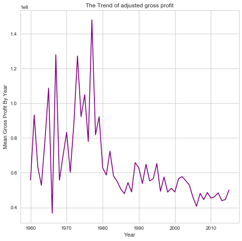

```python
MeanGrossProfit_byyear=df.groupby("release_year")["gross_profit_adj"].describe()["mean"]
IndexYear=MeanGrossProfit_byyear.index
locations=IndexYear
heights=MeanGrossProfit_byyear
labels=IndexYear
plt.figure(figsize=(8,8))
plt.plot(locations,heights,color="purple")
plt.title("The Trend of adjusted gross profit")
plt.xlabel("Year")
plt.ylabel("Mean Gross Profit By Year");
```

### 研究问题 3

### 按照不同的年份分组，电影的受欢迎度有什么趋势？

```python
df.groupby("release_year").describe()['popularity']
```

| release_year | count | mean | std | min | 25% | 50% | 75% | max |
| --- | --- | --- | --- | --- | --- | --- | --- | --- |
| 1960 | 32.0 | 0.458932 | 0.541833 | 0.055821 | 0.158091 | 0.268273 | 0.434118 | 2.610362 |
| 1961 | 31.0 | 0.422827 | 0.526517 | 0.027527 | 0.184113 | 0.265092 | 0.388336 | 2.631987 |
| 1962 | 32.0 | 0.454783 | 0.555945 | 0.038819 | 0.209852 | 0.299075 | 0.521489 | 3.170651 |
| 1963 | 34.0 | 0.502706 | 0.551040 | 0.045417 | 0.184746 | 0.249940 | 0.655374 | 2.508235 |
| 1964 | 42.0 | 0.412428 | 0.620196 | 0.008990 | 0.128546 | 0.194472 | 0.366349 | 3.153791 |
| 1965 | 35.0 | 0.342587 | 0.400366 | 0.004770 | 0.143120 | 0.201703 | 0.323553 | 1.910465 |
| 1966 | 46.0 | 0.304112 | 0.239278 | 0.034555 | 0.142370 | 0.245917 | 0.391831 | 1.227582 |
| 1967 | 40.0 | 0.471154 | 0.593532 | 0.034181 | 0.145091 | 0.240558 | 0.508377 | 2.550704 |
| 1968 | 39.0 | 0.484202 | 0.552789 | 0.005265 | 0.177678 | 0.323826 | 0.665733 | 3.309196 |
| 1969 | 31.0 | 0.422778 | 0.379827 | 0.002757 | 0.181642 | 0.337430 | 0.548311 | 1.778746 |
| 1970 | 41.0 | 0.341700 | 0.301852 | 0.020760 | 0.194705 | 0.284436 | 0.388100 | 1.936962 |
| 1971 | 55.0 | 0.448112 | 0.545079 | 0.000188 | 0.141973 | 0.306073 | 0.541644 | 3.072555 |
| 1972 | 40.0 | 0.449054 | 0.882401 | 0.024345 | 0.183973 | 0.265530 | 0.417693 | 5.738034 |
| 1973 | 55.0 | 0.494462 | 0.447417 | 0.021941 | 0.202036 | 0.383880 | 0.652778 | 2.272486 |
| 1974 | 47.0 | 0.447829 | 0.549779 | 0.029670 | 0.180903 | 0.310640 | 0.452380 | 3.264571 |
| 1975 | 44.0 | 0.519445 | 0.660684 | 0.017468 | 0.175472 | 0.315883 | 0.516772 | 3.258151 |
| 1976 | 47.0 | 0.474516 | 0.510478 | 0.002381 | 0.194671 | 0.328263 | 0.567103 | 2.582657 |
| 1977 | 57.0 | 0.626387 | 1.597408 | 0.002457 | 0.140163 | 0.312358 | 0.520725 | 12.037933 |
| 1978 | 65.0 | 0.413314 | 0.371321 | 0.044675 | 0.154407 | 0.296883 | 0.496029 | 1.697618 |
| 1979 | 57.0 | 0.589312 | 0.781610 | 0.019263 | 0.164320 | 0.360116 | 0.567776 | 4.935897 |
| 1980 | 78.0 | 0.495652 | 0.719202 | 0.031133 | 0.155749 | 0.286264 | 0.572022 | 5.488441 |
| 1981 | 82.0 | 0.442413 | 0.595353 | 0.046679 | 0.157701 | 0.280764 | 0.495645 | 4.578300 |
| 1982 | 81.0 | 0.543353 | 0.651902 | 0.003659 | 0.174119 | 0.374830 | 0.608984 | 4.215642 |
| 1983 | 80.0 | 0.541445 | 0.674568 | 0.002120 | 0.209832 | 0.353356 | 0.579059 | 4.828854 |
| 1984 | 105.0 | 0.590843 | 0.669988 | 0.059713 | 0.222379 | 0.367854 | 0.627167 | 4.831966 |
| 1985 | 109.0 | 0.584058 | 0.691560 | 0.000065 | 0.225650 | 0.393705 | 0.688022 | 6.095293 |
| 1986 | 121.0 | 0.509545 | 0.392233 | 0.001567 | 0.253984 | 0.389778 | 0.642842 | 2.485419 |
| 1987 | 125.0 | 0.504637 | 0.488404 | 0.005529 | 0.207159 | 0.345753 | 0.598029 | 3.474728 |
| 1988 | 145.0 | 0.465039 | 0.471536 | 0.001662 | 0.195211 | 0.321068 | 0.538522 | 3.777441 |
| 1989 | 137.0 | 0.563658 | 0.680101 | 0.010016 | 0.208511 | 0.355479 | 0.531317 | 4.143585 |
| 1990 | 132.0 | 0.535735 | 0.540356 | 0.024987 | 0.242565 | 0.385163 | 0.552860 | 2.679627 |
| 1991 | 133.0 | 0.501090 | 0.527557 | 0.048237 | 0.231710 | 0.350342 | 0.621413 | 3.852269 |
| 1992 | 133.0 | 0.582913 | 0.658478 | 0.006863 | 0.250137 | 0.437073 | 0.687197 | 4.586426 |
| 1993 | 178.0 | 0.547056 | 0.436277 | 0.012941 | 0.263694 | 0.451882 | 0.701772 | 2.571339 |
| 1994 | 184.0 | 0.668825 | 1.016537 | 0.061916 | 0.254781 | 0.416888 | 0.676257 | 8.093754 |
| 1995 | 175.0 | 0.710722 | 0.693110 | 0.013131 | 0.309044 | 0.502955 | 0.838666 | 4.765359 |
| 1996 | 204.0 | 0.604768 | 0.562379 | 0.028143 | 0.300851 | 0.454557 | 0.703379 | 4.480733 |
| 1997 | 192.0 | 0.712003 | 0.797906 | 0.022145 | 0.261025 | 0.465463 | 0.827558 | 6.668990 |
| 1998 | 210.0 | 0.626165 | 0.585649 | 0.029699 | 0.233810 | 0.450006 | 0.792109 | 4.180540 |
| 1999 | 224.0 | 0.645799 | 0.937124 | 0.015074 | 0.215189 | 0.370755 | 0.733885 | 8.947905 |
| 2000 | 227.0 | 0.546799 | 0.555507 | 0.004010 | 0.195489 | 0.381729 | 0.693392 | 4.271452 |
| 2001 | 242.0 | 0.702658 | 0.967583 | 0.001349 | 0.225247 | 0.433135 | 0.745980 | 8.575419 |
| 2002 | 266.0 | 0.701454 | 0.855816 | 0.009266 | 0.240294 | 0.458767 | 0.891469 | 8.095275 |
| 2003 | 281.0 | 0.719083 | 0.975004 | 0.013546 | 0.226503 | 0.422711 | 0.820611 | 7.122455 |
| 2004 | 307.0 | 0.722438 | 0.784169 | 0.001117 | 0.244322 | 0.455263 | 0.910344 | 5.827781 |
| 2005 | 364.0 | 0.628663 | 0.704428 | 0.000973 | 0.225620 | 0.414138 | 0.749498 | 5.939927 |
| 2006 | 408.0 | 0.606371 | 0.678489 | 0.001115 | 0.218592 | 0.404138 | 0.731740 | 5.838503 |
| 2007 | 438.0 | 0.593161 | 0.623138 | 0.004196 | 0.215783 | 0.410970 | 0.679887 | 4.965391 |
| 2008 | 496.0 | 0.584817 | 0.725798 | 0.001317 | 0.199371 | 0.375307 | 0.697880 | 8.466668 |
| 2009 | 533.0 | 0.600178 | 0.812760 | 0.001423 | 0.216906 | 0.381469 | 0.652939 | 9.432768 |
| 2010 | 489.0 | 0.645058 | 0.825535 | 0.004433 | 0.213623 | 0.400305 | 0.778440 | 9.363643 |
| 2011 | 540.0 | 0.675069 | 0.867912 | 0.002006 | 0.224379 | 0.418728 | 0.812978 | 8.411577 |
| 2012 | 588.0 | 0.607197 | 0.867856 | 0.001372 | 0.165586 | 0.333248 | 0.635765 | 7.637767 |
| 2013 | 659.0 | 0.627627 | 0.828403 | 0.000620 | 0.170239 | 0.347558 | 0.744352 | 6.112766 |
| 2014 | 700.0 | 0.887268 | 1.752150 | 0.002599 | 0.178592 | 0.369884 | 0.796972 | 24.949134 |
| 2015 | 629.0 | 1.030657 | 2.233958 | 0.003920 | 0.203224 | 0.394466 | 0.956096 | 32.985763 |

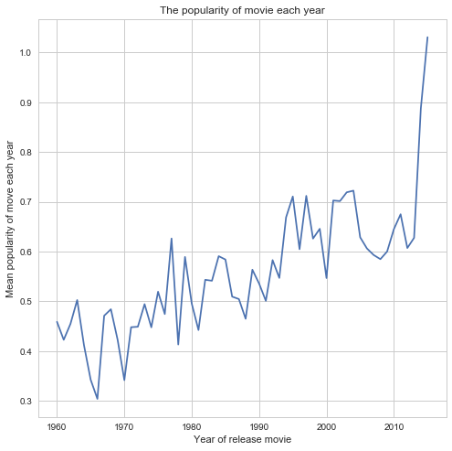

```python
meanofpopularity=df.groupby("release_year").describe()['popularity']['mean']
index_pop=meanofpopularity.index
locations=index_pop
heights=meanofpopularity
labels=index_pop
plt.figure(figsize=(8,8))
plt.plot(locations,heights)
plt.title("The popularity of movie each year")
plt.xlabel("Year of release movie")
plt.ylabel("Mean popularity of move each year");
```

### 研究问题 4

### 按照不同的年份分组，电影的发行数量是否越来越多了？

```python
df.groupby("release_year").count()["id"]
```

```
release_year
1960     32
1961     31
1962     32
1963     34
1964     42
1965     35
1966     46
1967     40
1968     39
1969     31
1970     41
1971     55
1972     40
1973     55
```

[output cut: 43 more lines]

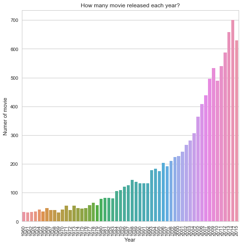

```python
count_movie=df.groupby("release_year").count()["id"]
count_movie_index=count_movie.index
width=count_movie_index
heights=count_movie
plt.figure(figsize=(8,8))
sns.barplot(width,heights,tick_label=b1)
plt.xticks(rotation='vertical')
plt.title("How many movie released each year?")
plt.xlabel("Year")
plt.ylabel("Numer of movie");
```

### 研究问题 5

### 根据上映年份的不同，每年的平均毛利润和每年的平均评分有什么关系？

```python
df.groupby("release_year")["vote_average"].describe()['mean']
```

```
release_year
1960    6.325000
1961    6.374194
1962    6.343750
1963    6.329412
1964    6.211905
1965    6.194286
1966    6.128261
1967    6.242500
1968    6.379487
1969    5.961290
1970    6.417073
1971    6.420000
1972    6.535000
1973    6.703636
```

[output cut: 43 more lines]

```python
df.groupby("release_year")["gross_profit_adj"].mean()
```

```
release_year
1960    5.584147e+07
1961    9.321909e+07
1962    6.328113e+07
1963    5.280552e+07
1964    7.909338e+07
1965    1.086866e+08
1966    3.677852e+07
1967    1.278615e+08
1968    5.574952e+07
1969    6.989098e+07
1970    8.329744e+07
1971    6.028308e+07
1972    8.819693e+07
1973    1.271538e+08
```

[output cut: 43 more lines]

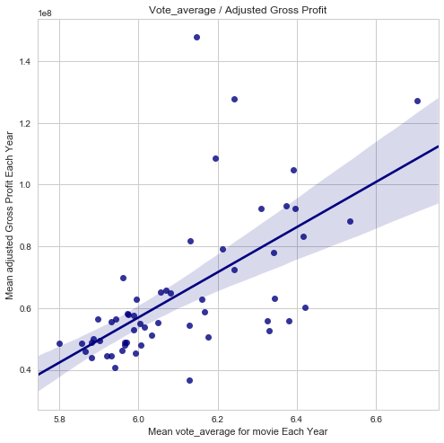

```python
mean_vote_average=df.groupby("release_year")["vote_average"].describe()['mean']
men_gross_profit=df.groupby("release_year")["gross_profit_adj"].mean()
plt.figure(figsize=(8,8))
sns.regplot(x=mean_vote_average,y=men_gross_profit,color="navy")
plt.title("Vote_average / Adjusted Gross Profit")
plt.xlabel("Mean vote_average for movie Each Year")
plt.ylabel("Mean adjusted Gross Profit Each Year");
```

### 研究问题 6

### 根据上映年份的不同，每年电影的平均评分走势是如何？

```python
df.groupby("release_year")["vote_average"].describe()['mean']
```

```
release_year
1960    6.325000
1961    6.374194
1962    6.343750
1963    6.329412
1964    6.211905
1965    6.194286
1966    6.128261
1967    6.242500
1968    6.379487
1969    5.961290
1970    6.417073
1971    6.420000
1972    6.535000
1973    6.703636
```

[output cut: 43 more lines]

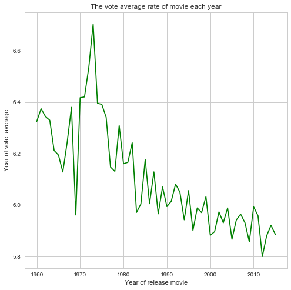

```python
mean_vote_average_byyear=df.groupby("release_year")["vote_average"].describe()['mean']
indexmean_vote=mean_vote_average_byyear.index
locations=indexmean_vote
heights=mean_vote_average_byyear
labels=indexmean_vote
plt.figure(figsize=(8,8))
plt.plot(locations,heights,color="g")
plt.title("The vote average rate of movie each year")
plt.xlabel("Year of release movie")
plt.ylabel("Year of vote_average");
```

### 研究问题 7

### 用来描述电影最常用的关键字是什么？

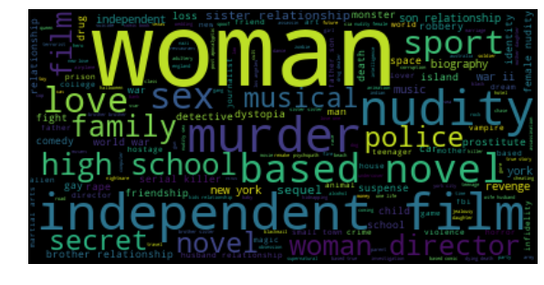

```python
wordcloud_keywords = WordCloud(max_font_size=80).generate(''.join(df["keywords"]))
WordCloud.generate_from_frequencies
plt.figure(figsize=(10,10))
plt.imshow(wordcloud_keywords, interpolation='bilinear')
plt.axis("off");
```

## 结论

> 1.1对于每一年评分最高的电影，这些电影的类型集中在哪些类型？

> **根据图表，1960-2015年，评分最高的电影，主要集中在Action,Drama,Science Fiction,Adventure等类型。**

> 2.按照不同的年份分组，根据调整过的预算和收益，电影的毛利润有什么趋势？

> **根据图表，我们可以看到是呈下降趋势。**

> 3.按照不同的年份分组，电影的受欢迎度有什么不同？

> **根据图表，我们可以看到是呈上升趋势。也就是越晚的电影，在相关页面上被查看的次数越大。**

> 4.按照不同的年份分组，电影的发行数量是否越来越多了？

> **根据图表，我们可以看到是呈上升趋势，也就是1960-2015年，电影的发行数量总体上是越来越多了。**

> 5.根据上映年份的不同，每年的平均毛利润和每年的平均评分有什么关系？

> 6.根据上映年份的不同，每年电影的平均评分走势是如何？

> **根据图表，我们可以看到是呈下降趋势。**

> 7.最常被用来描述电影的关键字是什么？